# Case example 1: identify cell types in a sample

### Background:

For this case example we will use the dataset provided in the **Load data** tab. The Zip folder in the **Load data** tab contains the counts for the experiment in the three formats read by this app. Choose one ( RDS, H5, 10X genomics folder ), give a nave to the project and click the *Load dataset* button.

This dataset comes from a single sample of peripheral blood mononuclear cells. We will start with an initial number of 1225 cells, so we’ll expect to find at least the most common PBMC cell types:

- Classical and non-classical monocytes
- Naïve, helper, and cytotoxic T cells
- B cells
- NK cells

We might detect more uncommon cell types in PBMC samples (such as dendritic cells or platelets), but if their numbers are very low, or their transcriptome as a whole is not different enought, these cells might end up grouped together with similar cell types that are more common.

### Cleaning the dataset

After running the quality control analysis, we get the following plot for our raw data:

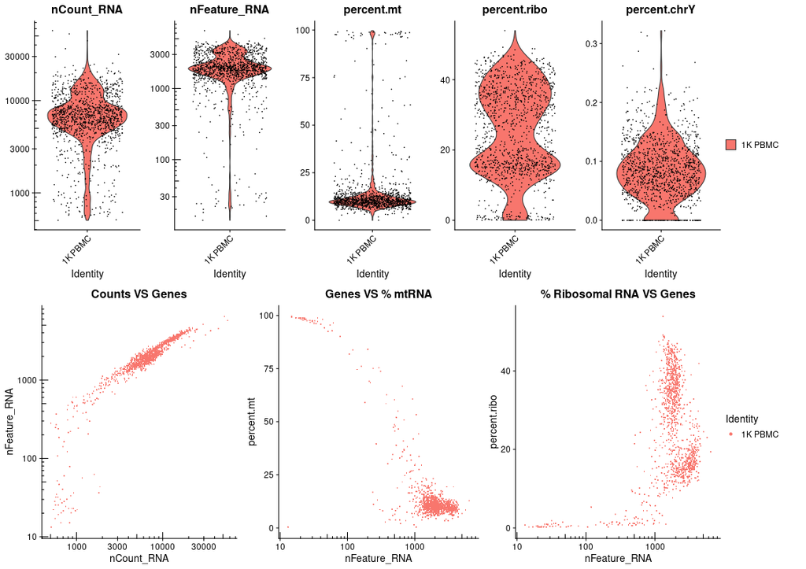

In the first row of plots we can see the distributions of genes detected, read counts, and percentages of reads corresponding to mitocondrial, ribosomal, and non-recombinant Y genes. NRY genes aren’t very relevant in this case, but when combining different samples, checking if there’s an imbalance of chromosome Y genes will allow us to account for the differences in gene expression due to variability in sex chromosome across samples.

A small amount of the cells in the dataset have very high percentages of mitocondrial RNA counts. Even though mitocondrial RNA is expressed in different ammounts scross different cell types, high levels of mt-RNA are more commonly associated apoptopic ot lysed cells. With the plots in the second row we can infer that estabishing a minimum of 1000 detected genes and 3000 read counts will filter out most of these cells.

The last plot on the bottom row, corresponding to the percentage of ribosomic RNA, works similarly to mitocondrial RNA, but in this is very clear that we have two groups with different proportions of ribosomal RNA, instead of a small trail of outliers. In cases like this we will most likely keep these cells and later check if the high levels of ribosomal RNA can have a biological reason.

Next, we’ll take a look at cell cycle scoring. In the corresponding plot below we can see most cells clump together, so we would expect that, even though come cells might be cycling, this doesn’t seem to have a large influence on our dataset.

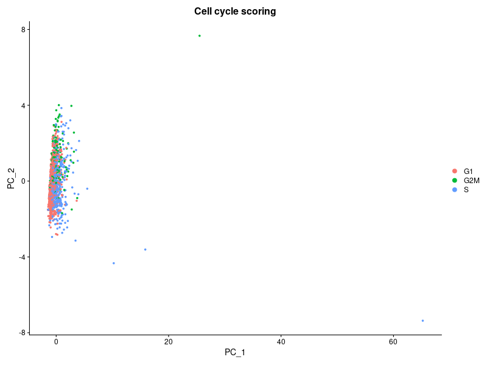

After filtering cells by their read count and the number of genes detected, we’ll keep 1081 cells. In addition, we can regress the effects of the percentage of mitocondrial RNA and cell cycle scores. Lastly, we will select to perform SCT normalizacion.

Internally, the program will store the normalized expression values of genes that have high variability. This means that genes that could be considered “housekeeping genes” in our sample, as well as those whose expression isn’t strong enought to be consistently detected, won’t be take into account to cluster the cells.

### Tunning clustering parameters

The basis to classify our cells into cluster will be their normalized expression values of the variable genes mentioned in the last paragraph. Results of running a clustering algorithm will vary depending on the parameters we set and there’s not a definitive answer as to what the correct result is. Considering this, we’ll start exploring the effects of using a ranges of values as our clustering parameters to find which are better suited to our dataset and the biological question we’re trying to solve.

Well start with the number of PCA components used as input. As is explained in the users guide, a Principal Component Analysis of a dataset is a technique to condense the information in said dataset, and thus, reduce the number of variables we need to define the elements in the dataset. In the case of scRNA-seq datasets, each component of a PCA will consist of a linear combination of the expression of several genes, so the information given by several thousands of genes will be condensed in a maximum of 50 variables.

Now, the first few components of the PCA will give us a lot of information about the cells in the experiment, but with each new component we add, we’ll get fewer and fewer extra details about our sample, to the point where the added information is not worth the resources of working with a larger matrix.

What is the appropiate number of printcipal components to keep going forward? That will depend on the population size and complexity of our sample. It’s possible to infer this examining the standard deviation of the values in each principal component and looking for the point where standar deviation stops falling.

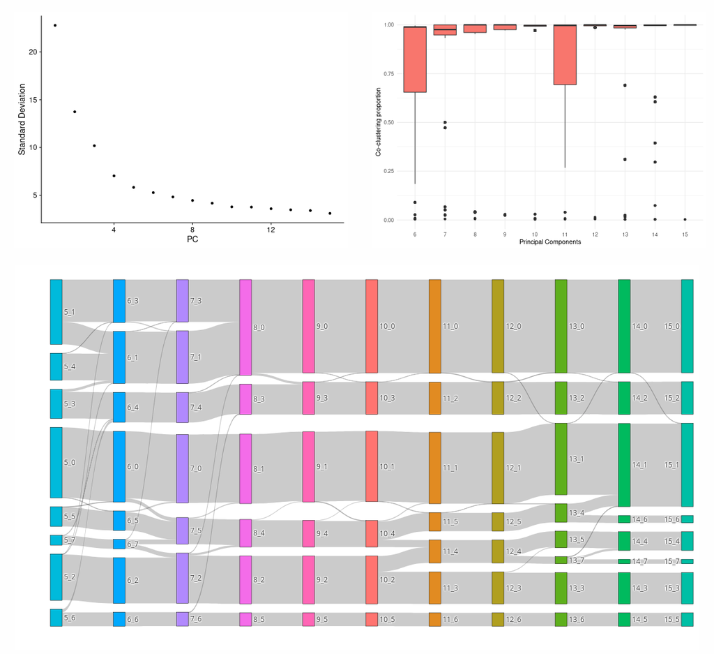

For this dataset, the initial recommendation is to use 10 principal components. As we can see in the co-clustering and flow plots, there is a large rearrangement between using 10 and 11 principal components. This rearrangement might be an interesting option, so we will check the influence of clustering resolution for both 10 and 11 principal components. Since we have a small dataset, in this case we will pay more attention to smaller resolution values.

Here is the co-clustering conservation across different resolution values for 10 PCs:

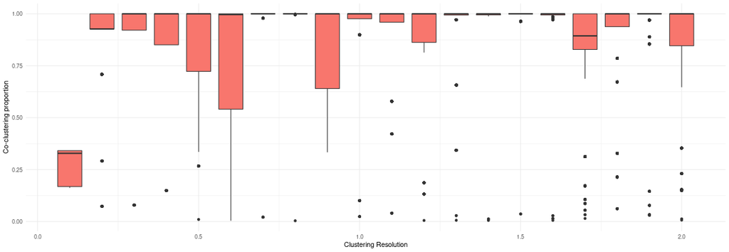

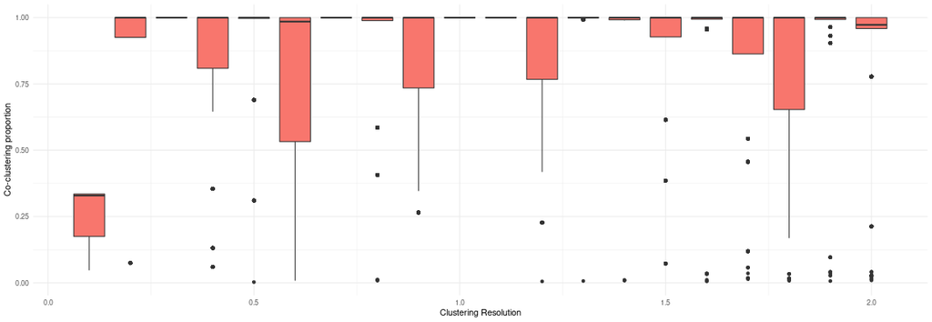

As we can see, there tends to be less rearrangements using 11 PCs, specially in resolutions <1, but the changes between 0.1-0.2, 0.3-0.4, and 0.5-0.6 seem quite simillar. It might be the case that the same changes are ocurring in both cases, but more gradually when using 10 PCs than using 11.

Next, let’s look at clustering flow plots and uncertainty scores. First, using 10 principal components:

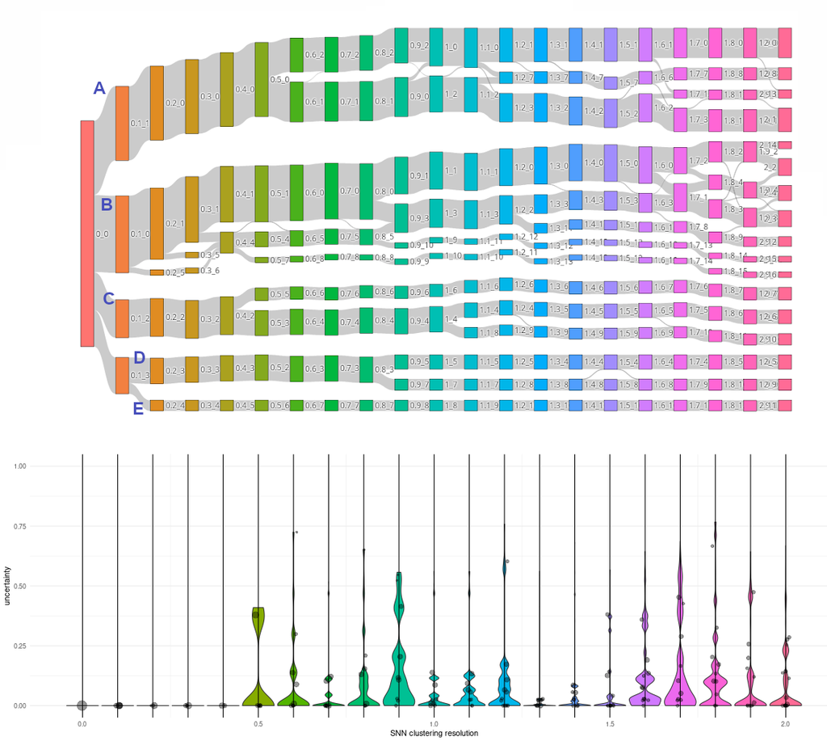

And using 11 principal components:

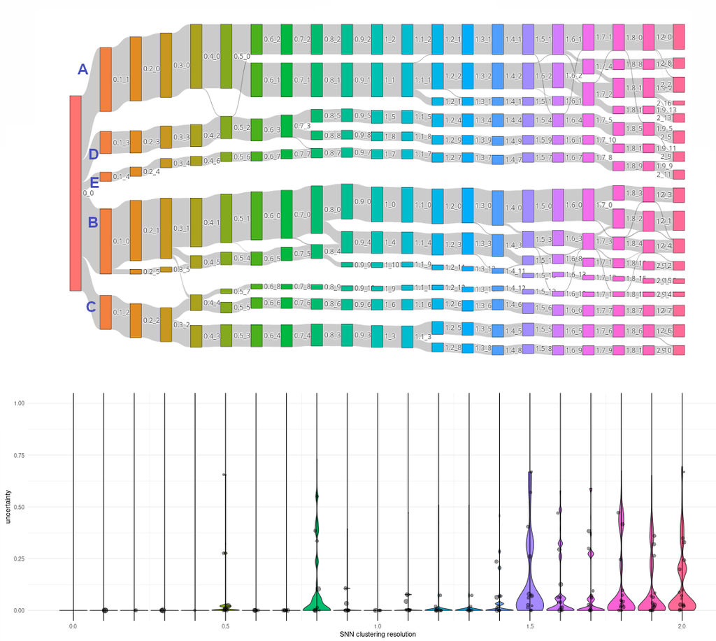

In both cases the cell population is divided early into five main blocks (labeled A-E in the images to make them more easily recognizable) and uncertainty scores are kept at a minimal values at resolutions <0.5. The main divergence at low resolution values is how the smallest cluster is formed, being linked to block B in the first case, and block C in the second. Since it doesn’t appear to be significant improvements using 11 principal components, we will proceed using 10.

As for the clustering resolution, there would be two recommended values for which the classification in clusters is more stable, one more general at 0.4, resuting in 6 clusters, and one more granular at 1.3, resulting in 14 clusters. For this tutorial, we’ll move forward using the lowest resolution (0.4) to obtain a general classification

**Interpreting uncertainty scores**

In some cases uncertainty raises sharply and then decreases again, like it does here at a clustering resolution of 0.5. This happens when a reorganization is not stable yet: if we pick a lower resolution and run the clustering algorithm several times, a group of cells is always kept together; if we pick a higher resolutions, that group is always split, but with a resolution value in the middle, in some iterations the group will be split and in others it won’t, resulting in drastic “peaks” in uncertainty scores.

When there are gradual changes in uncertainty scores the goal is finding local minimums, in which the resulting classification of the cells in clusters resembles more closely the underlying sample’s cell type diversity. It is important to keep in mind that with higher values of clustering resolution we’ll tend to get more clusters, but smaller. This will impact results in other analisys such as differential expression or cell type imputation.

Choosing clustering parameters is thighly linked to the biological question we’re trying to solve, sometimes a general classification will be more useful, and sometimes a detailed one will serve our purpose better. But whichever resolution we pick, there’s always the possibility to go a few steps back and redo the analysis with different parameters, so if several combinations of parameters seem to work well with the dataset, don’t hesitate to try one and decide later if a second analysis is needed.

As a recap, the clustering parameters chosen will be:

- Number of principal components: 10
- Clustering resolution: 0.4

### Creating 2D visualizations

2D plots will help us visualize and communicate information about our dataset. Since tSNE and UMAP algorithms also allow us to use several parameters that will change a bit the results that we get, let’s start by exploring some of the options we have. First, lets’s set parameters based on dataset size. This will give us a set of plots using different parameters for the tSNE and UMAP algorithms.

Here are the tSNE results:

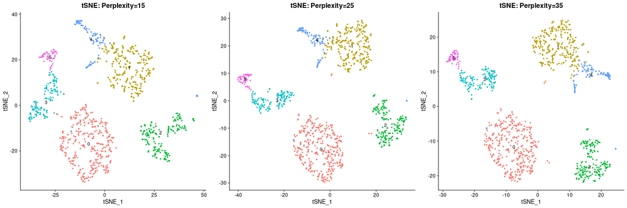

And the UMAP ones:

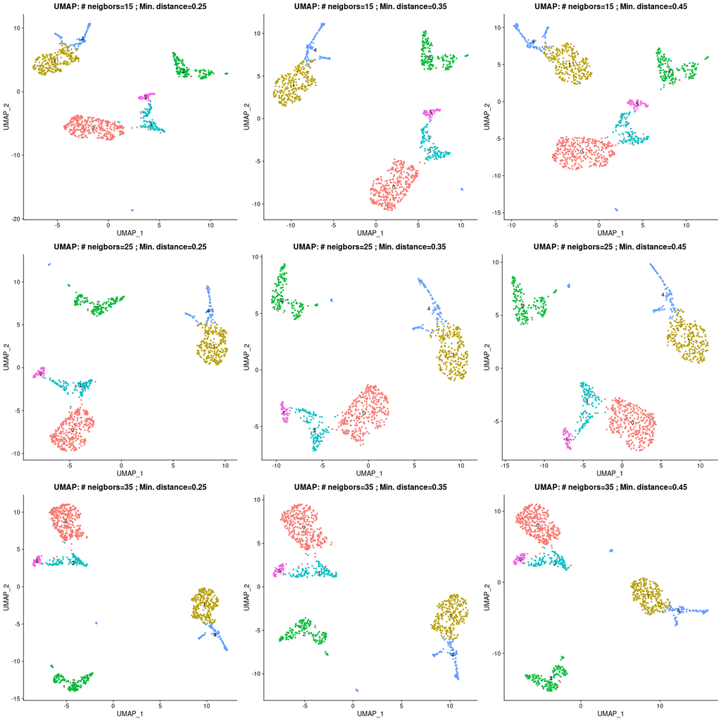

As explained in the user’s guide, to generate this plots the app wil use the same normalized expression data as the clustering algorithm, so the results of both ussualy match pretty well.

Unless we plan to specifically use these tSNE/UMAP reductions as input for another program -for instance, some trajectory analysis software uses them-, their function will be only as a tool to display information (gene expression, assigned cell type, other experiment metadata, etc). Because of that, we would prioritize embeddings that would allow to add comfortably legible labels and cell clusters are as easy to distinguish as possible.

In general, tSNE embeddings tend to leave cells more “dispersed” and can take more time to compute, but we are working with a small dataset so tSNE will give us good 2D visualization plots without spending too much resources.

If we’re not fully satisfied with the cells’ positioning, we could fix the perplexity parameter and seet the algorithm’s seed to random samples, which will give us some variations:

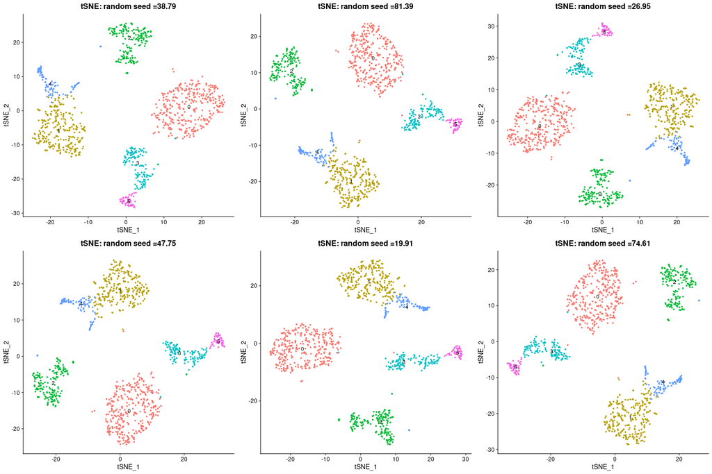

Once we have decided on the parameters, we can select the option *“Generate an embedding for the dataset”*, so the 2D reduction generated is saved internally with the experiment’s data.

**A fork in the path**

At this point we have two options to identify cell types in our sample:

- If we want to use the automatic annotation system, we can jump directly to the cell type imputation tab, since the program implemented, scCATCH will test for differential expression on its own.
- Otherwhise, if we prefer to use a custom selection of cell type markers, we’ll have to calculate differential expression between clusters first.

### Differential expression

To assign cell types to each cluster we need to know what differenciates each cluster from the rest of cells, so we’ll select the following options:

- Grouping variable: the field that stores the clustering results, in this example, “*Clustering_res_0.4*”.
- Analisys mode: “*1 VS rest*”.

After running the analysis, this is a summary of the results:

| Comparison | Cells in Foreground | Cells in Background | Total DEG | Up regulated Genes | Down regulated Genes |
| --- | --- | --- | --- | --- | --- |
| 0 VS rest | 355.00 | 33183.00 | 1489 | 246 | 1243 |
| 1 VS rest | 268.00 | 33270.00 | 2049 | 1726 | 323 |
| 2 VS rest | 182.00 | 33356.00 | 924 | 261 | 663 |
| 3 VS rest | 124.00 | 33414.00 | 515 | 195 | 320 |
| 4 VS rest | 101.00 | 33437.00 | 1502 | 1429 | 73 |
| 5 VS rest | 51.00 | 33487.00 | 413 | 332 | 81 |

We can take a look at the top DE genes for each cluster, and also see a heatmap of the top 5 up-regulated genes in each cluster:

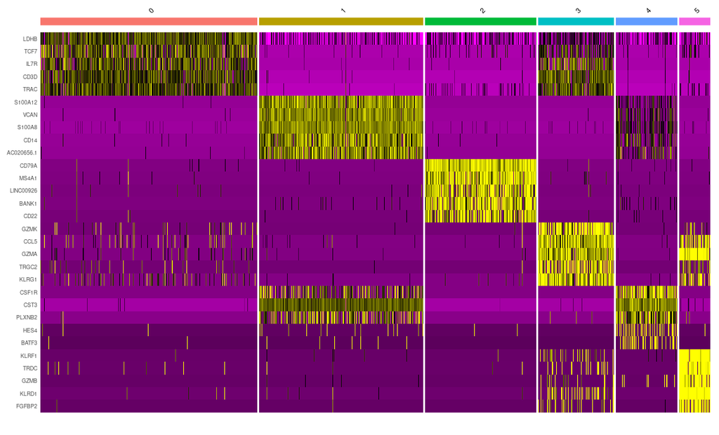

Just by this heatmap we can already see that there are similarities between clusters 1-4 and 3-5, which were also closer in the clustering flow plots and are adjacent in the tSNE embedding.

### Cell type imputation

In manual annotation mode, the grouping variable will be selected depending on what was used to calculate differential expression. Let’s continue introducing some common markers for PBMCs:

| Cell.Type | Markers |
| --- | --- |
| Naive CD4+ T | IL7R, CCR7 |
| CD14+ Monocyte | CD14, LYZ |
| Memory CD4+ | IL7R, S100A4 |
| B cell | MS4A1 |
| CD8+ T | CD8A |
| FCGR3A+ Monocyte | FCGR3A, MS4A7 |
| Natural killer | GNLY, NKG7 |
| Dendritic cell | FCER1A, CST3 |
| Platelet | PPBP |

A summary of the results:

| Group | Size | DE analysis mode | Num of DEGs | Num of up genes | Num of down genes | Markers UpReg | Markers DownReg | Putative cell type |
| --- | --- | --- | --- | --- | --- | --- | --- | --- |
| 0 | 355.00 | 1 VS rest | 1489 | 246 | 1243 | IL7R, CCR7, IL7R | CD14, LYZ, S100A4, MS4A1, MS4A7, NKG7, CST3 | Naive CD4+ T |
| 1 | 268.00 | 1 VS rest | 2049 | 1726 | 323 | CD14, LYZ, S100A4, MS4A7, CST3 | IL7R, CCR7, IL7R, NKG7 | CD14+ Monocyte |
| 2 | 182.00 | 1 VS rest | 924 | 261 | 663 | MS4A1 | IL7R, CD14, LYZ, IL7R, S100A4, MS4A7, NKG7, CST3 | B cell |
| 3 | 124.00 | 1 VS rest | 515 | 195 | 320 | IL7R, IL7R, GNLY, NKG7 | CD14, LYZ, MS4A7, CST3 | Natural killer |
| 4 | 101.00 | 1 VS rest | 1502 | 1429 | 73 | LYZ, S100A4, FCGR3A, MS4A7, FCER1A, CST3 | IL7R, CCR7, IL7R | Dendritic cell |
| 5 | 51.00 | 1 VS rest | 413 | 332 | 81 | FCGR3A, GNLY, NKG7 | IL7R, IL7R | Natural killer |

Here we have a plot of the clusters with their assigned cell types:

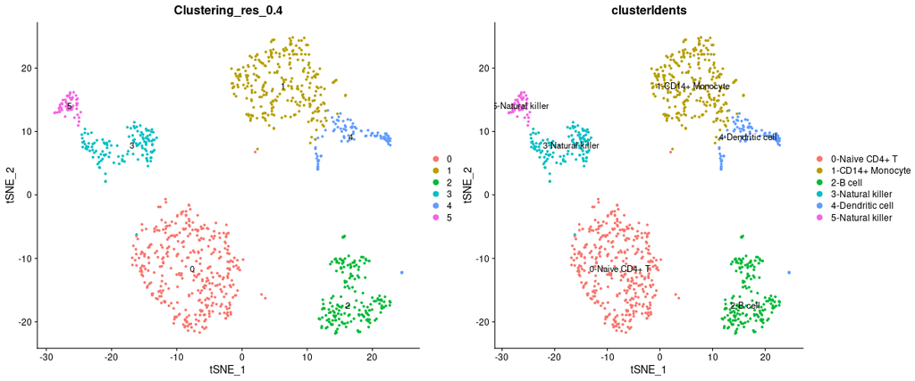

By default clusters will be assigned to the cell type whose markers have higher up-regulation levels, but if our classification into clusters was more general -like in this example- it is common to have clusters with more than one cell type. We can see that this is happening in cluster 4 looking at the “*Markers UpReg*” column of the summary table, were the markers for both dendritic cells and FCGR3A+ monocites are up-regulated. This is also visible in the ring plot for this cluster:

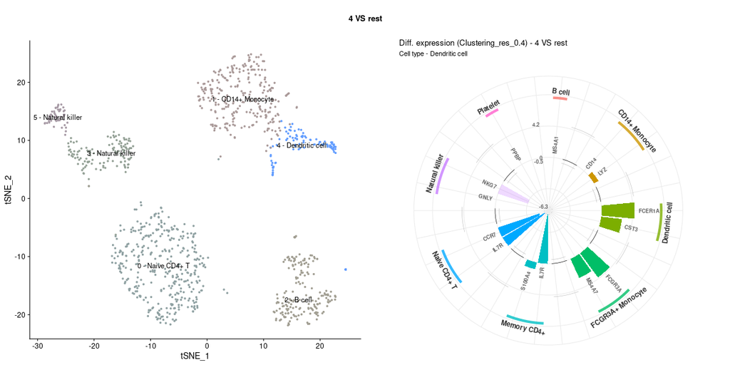

At this point, depending on the size of our dataset and the context in which our analysis takes place, we would decide if a more detailed analysis its necessary, and whether the more appropiate course of action could be:

- Redo the analysis running the clustering algorithm with a higher resolution.
- Make a subset of the cell, selecting only a few clusters of interest to re-analyze.

The option is interesting specially in cases with more than one sample and / or several experimental conditions, or where the main focus of the study are specific cell types.